# Week 7

Text Mining

# Introduction

We’re in the age of big data, and text mining has never been more popular or easier to do, especially in R. Whether you are a qualitative researcher looking to automate more of your workflow or a quant seeking to pull insights from a corpus of messages, text mining is a skill you need.

My first experience with text mining was in graduate school, probably around 2006. A friend wrote me a PERL script to pull all of the wires from *LexisNexis* mentioning the Lord’s Resistance Army going back 20 years. Wires have a standard format, so we were able to extract the date, location, and casualty figures for each attack. I had to do a lot of manual clean-up, but it was magic.

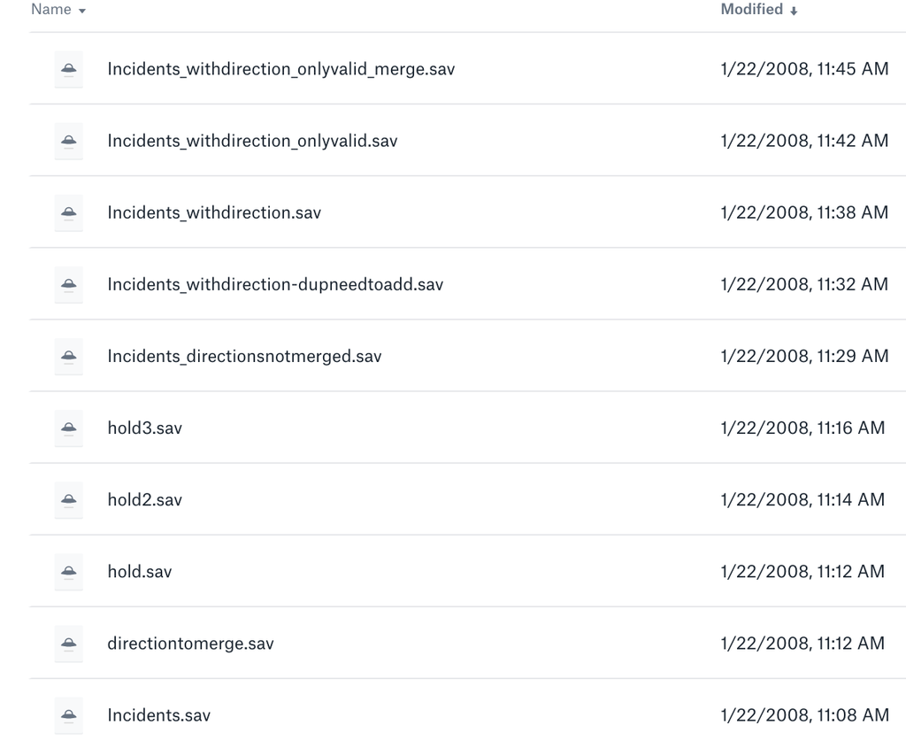

Figure 1: Graduate school me worked in SPSS and named files like an animal.

Fast forward about a decade and I returned to text mining in my work with Nivi. I was sitting on a corpus of nearly 180,000 text messages, and I needed a way to analyze them automatically. Fortunately for me, Julia Silge and David Robinson wrote a book and package called [`{tidytext}`](https://www.tidytextmining.com/) and gave both away for free. My colleagues and I [published a paper](https://gatesopenresearch.org/articles/3-1475) with an accompanying tutorial on how to use the package. We found astonishing results about what men of all age groups want to discuss.

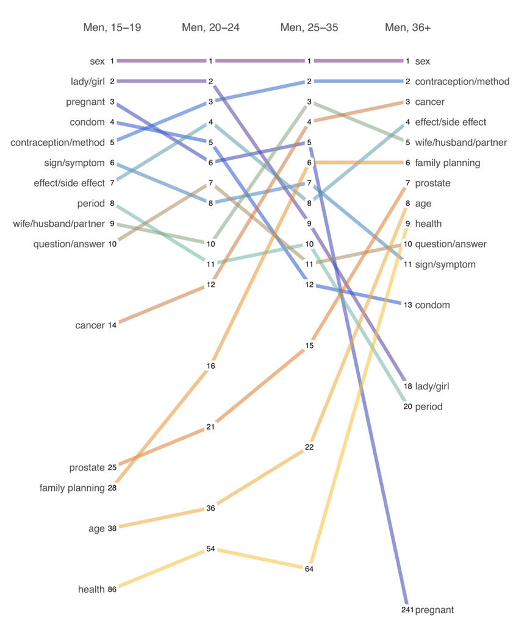

Figure 2: Slope chart showing the most frequently used words by men, disaggregated by age group. Source: [Green et al., 2019](https://gatesopenresearch.org/articles/3-1475).

# The `{tidytext}` package

This package makes working with text data a breeze. It follows Wickham’s priciples of tidy data we reviewed earlier in this workshop series:

- Each variable is a column
- Each observation is a row
- Each type of observational unit is a table

The “tidy” in `{tidytext}` is defined as a table with one-token-per-row, where “token” means a unit of text for analysis, like a word. Take the song, “Time to Tidy Up”, by Dave Moran:

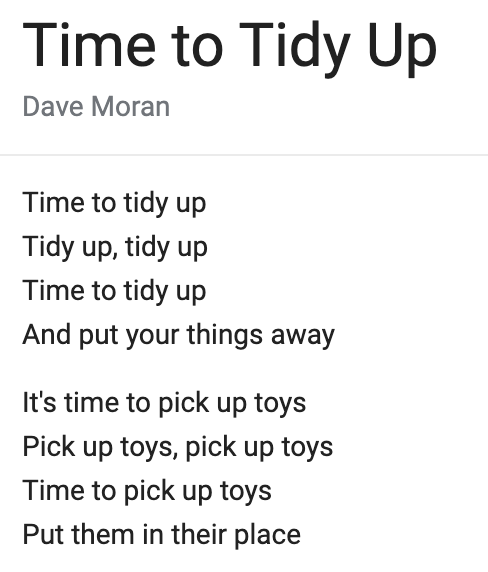

Figure 3: [Time to Tidy Up](https://www.lyrics.com/lyric/11841616/Dave+Moran/Time+to+Tidy+Up), by Dave Moran.

We can use the `unnest_tokens()` function to tokenize these song lyrics into individual words and organize into a tidy data format.

Table 1: A tidy tokenized version of Time to Tidy Up.

| song | word |
| --- | --- |
| Time to Tidy Up | time |
| Time to Tidy Up | to |
| Time to Tidy Up | tidy |
| Time to Tidy Up | up |
| Time to Tidy Up | tidy |
| Time to Tidy Up | up |
| Time to Tidy Up | tidy |
| Time to Tidy Up | up |
| Time to Tidy Up | time |
| Time to Tidy Up | to |
| Time to Tidy Up | tidy |
| Time to Tidy Up | up |
| Time to Tidy Up | and |
| Time to Tidy Up | put |
| Time to Tidy Up | your |
| Time to Tidy Up | things |
| Time to Tidy Up | away |

`unnest_tokens()` made our job easy by removing punctuation and converting all text to lowercase by default. Now we can get on with summarizing and visualizing the data.

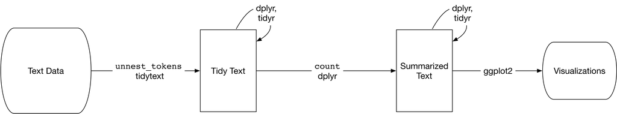

Figure 4: Text analysis flow diagram. Source: [Silge and Robinson (2020)](https://www.tidytextmining.com/tidytext.html).

# Data for today

The data for today’s tutorial come from the President’s Twitter timeline.

> The Coronavirus is very much under control in the USA. We are in contact with everyone and all relevant countries. CDC & World Health have been working hard and very smart. Stock Market starting to look very good to me!

> — Donald J. Trump (@realDonaldTrump) [February 24, 2020](https://twitter.com/realDonaldTrump/status/1232058127740174339?ref_src=twsrc%5Etfw)

There are several good packages for working with Twitter data in R. The most feature-packed package is probably [`{rtweet}`](https://rtweet.info/).

[figure not shown]

Figure 5: Package comparisons. Source: [`{rtweet}` package](https://rtweet.info/).

We won’t use any of these packages today because Twitter requires you to create a free developer account to access the API. The process is not hard, it just takes more time than we have. You can follow [the steps outlined here](https://cran.r-project.org/web/packages/rtweet/vignettes/auth.html) if you want to explore the Twitterverse with the tidyverse.

To speed things up, I prepared a csv file with all of the President’s tweets since December 10, 2019 when one of the first cases of COVID-19 in Wuhan, China started experiencing symptoms. Import this file and assign to the object `stableGenius`.

Table 2: Dataframe of the President’s tweets since December 10, 2019.

| text | created_at | favorite_count |
| --- | --- | --- |
| “The Massive Trump Coronavirus Supply Effort that the Media Loves to Hate” @RichLowry https://t.co/VChm4ELmKZ | 5/19/20 16:49 | 10068 |
| I am pleased to announce that the Seattle area’s @SoundTransit will receive over $166M in federal funds from @USDOT to help keep the transit system open & operational helping get people to work or mak… | 5/19/20 16:36 | 14078 |
| I am proud to announce the Portland Area’s @trimet will receive over $184M in federal funds to support continued operations of their transit system. This will keep workers on the job and help the econ… | 5/19/20 16:26 | 18140 |
| I am proud to announce the San Francisco Bay Area will receive over $700M in federal funds to support continued operations and support workers at @flySFO Intl Airport and for transit on @sfmta_muni & … | 5/19/20 16:25 | 15485 |
| DC’s @WMATA system is getting over $876M a big boost to stay open & operating! The federal funds will keep workers paid & buses & trains running on a limited schedule as they are needed for essential … | 5/19/20 16:22 | 13383 |
| .@foxandfriends trounces Morning Psycho (MSDNC) in the Ratings! | 5/19/20 13:29 | 60015 |
| This is the letter sent to Dr. Tedros of the World Health Organization. It is self-explanatory! https://t.co/pF2kzPUpDv | 5/19/20 2:55 | 222432 |
| .@FoxNews is no longer the same. We miss the great Roger Ailes. You have more anti-Trump people by far than ever before. Looking for a new outlet! https://t.co/jXxsF0flUM | 5/19/20 1:59 | 80269 |
| https://t.co/LQvPt19b8V | 5/19/20 0:33 | 42342 |
| https://t.co/Lwcyq5Pgpq | 5/19/20 0:26 | 38367 |

# Quick exploration

We can start by counting the number of tweets by date and plotting.

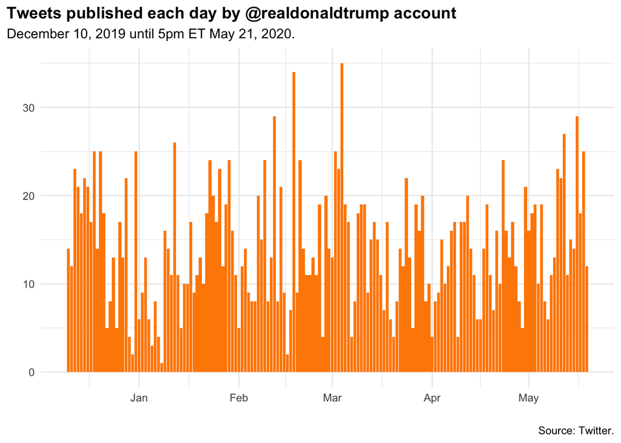

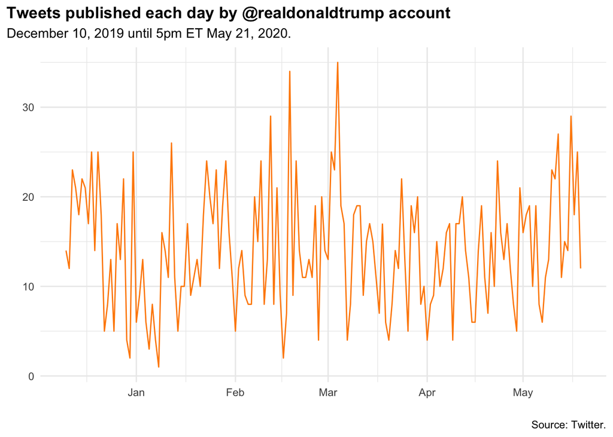

The daily sum is a bit noisy, so let’s try aggregating by week using `lubridate::floor_date()` and `group_by()`.

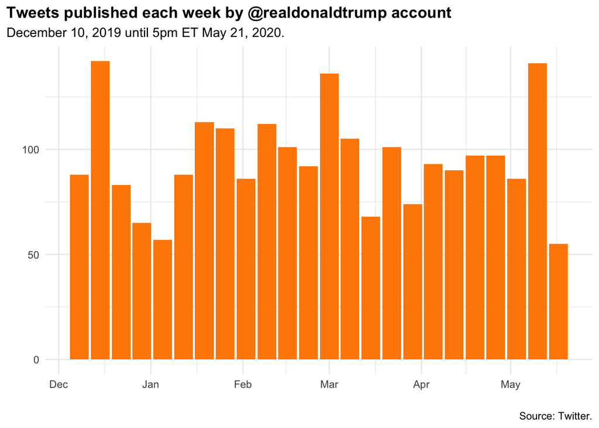

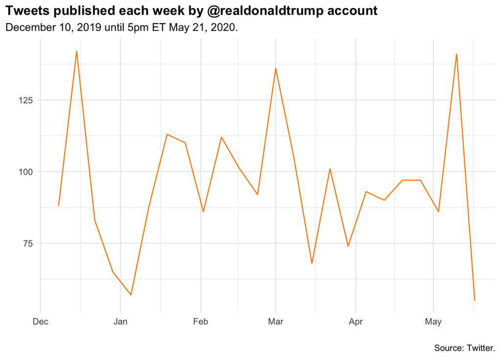

# Label COVID-19

The President tweets a lot, but how much of his timeline is COVID-19 related? With *only* 2280 tweets in our dataset, it would be reasonable to manually (qualitatively) “code” or label each tweet if we wanted to answer this question as part of a study. If there were 10x as many tweets, we might opt to manually label a few hundred and use this training dataset to build a machine learning classification model that predicts whether each tweet should be labeled as COVID-19 related or not.

Our ambitions this week are more modest, however, so we’ll simply identify a group of keywords the President tends to use in his COVID-19 messages and flag tweets that contain any of the keywords. It’s not perfect, but that’s OK because we’re just exploring. Don’t call CNN.

| covid | n |
| --- | --- |
| no | 2063 |
| yes | 217 |

To plot the relative make-up of the President’s tweets, we first need to count tweets by week and covid label. This gives a long(er) dataframe that we can pass to `ggplot()` along with `fill=covid`.

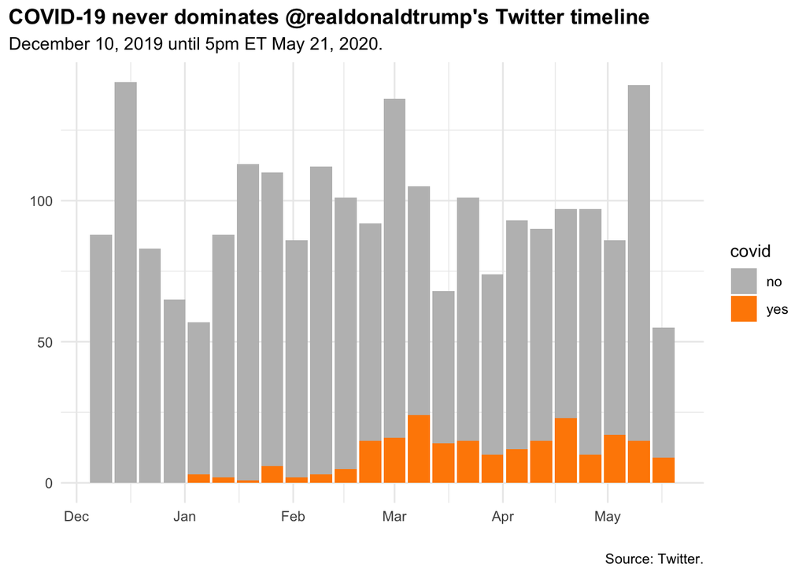

The overall number of tweets (aka, the denominator) varies by week, so we could take this one step further and calculate/plot the percentage of tweets that are related to COVID-19.

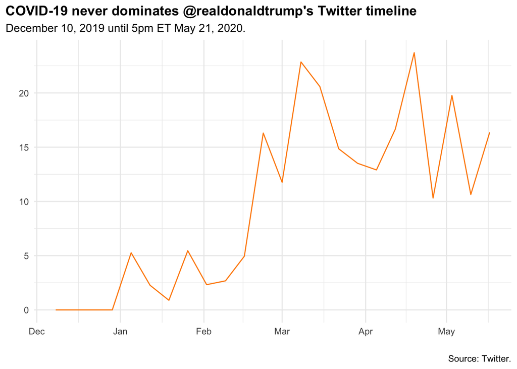

# Time to tokenize

To explore the data in a tidy text way, we need to tokenize into a 1-word-per-row format using `unnest_tokens()`. Before we get to this step, however, we need to remove all of the URLs in the President’s tweets. We’ll do this by setting a regular expressions (regex) pattern for URLs and using `str_remove_all()` to remove this pattern from the tweets.

How did I create this regex string? Like everyone else—I googled something. Only 3-5 people in the world know how to do this, so you have to ask them on Stack Overflow or find an existing answer. If you want to be one of the chosen few, start [here](https://stringr.tidyverse.org/articles/regular-expressions.html), read [this chapter](https://r4ds.had.co.nz/strings.html), and download [this cheatsheet](https://github.com/rstudio/cheatsheets/raw/master/regex.pdf).

| created_at | word |
| --- | --- |
| 2020-05-19 16:49:00 | the |
| 2020-05-19 16:49:00 | massive |
| 2020-05-19 16:49:00 | trump |
| 2020-05-19 16:49:00 | coronavirus |
| 2020-05-19 16:49:00 | supply |
| 2020-05-19 16:49:00 | effort |
| 2020-05-19 16:49:00 | that |
| 2020-05-19 16:49:00 | the |
| 2020-05-19 16:49:00 | media |
| 2020-05-19 16:49:00 | loves |
| 2020-05-19 16:49:00 | to |
| 2020-05-19 16:49:00 | hate |
| 2020-05-19 16:49:00 | richlowry |
| 2020-05-19 16:36:00 | i |
| 2020-05-19 16:36:00 | am |

As you can see from this table, our tokens include common words like “the” and “to”. These words are not informative in an analysis, so we’ll remove them with `anti_join()`. This is a filtering join:

> return all rows from x where there are not matching values in y, keeping just columns from x.

```
## [1] FALSE
```

| word | n |
| --- | --- |
| coronavirus | 83 |
| amp | 69 |
| testing | 37 |
| china | 34 |
| news | 34 |
| job | 33 |
| people | 29 |
| virus | 27 |
| fake | 23 |
| president | 23 |
| party | 21 |
| democrats | 20 |
| house | 20 |
| american | 19 |
| borders | 18 |

“amp” is a weird result, so let’s have a look at tweets that contain “amp”.

| text |
| --- |
| i am pleased to announce that the seattle area’s @soundtransit will receive over $166m in federal funds from @usdot to help keep the transit system open & operational helping get people to work or mak… |
| dc’s @wmata system is getting over $876m a big boost to stay open & operating! the federal funds will keep workers paid & buses & trains running on a limited schedule as they are needed for essential … |
| really sad but even “sadder” watch flunky @lawrence cry when i whipped his mind & he was forced to apologize to me over apprentice fees. even psycho cold case joe scarborough (bad ratings) beat him up… |
| california should let tesla & @elonmusk open the plant now. it can be done fast & safely! |
| ….gloves gowns etc. are now plentiful. the last four governors teleconference calls have been conclusively strong. because of this success the task force will continue on indefinitely with its focus o… |
| ….produced in the thousands and we have many to spare. we are helping other countries which are desperate for them. likewise after having been left little we are now doing more testing than all other … |
| the white house coronavirus task force headed by vice president mike pence has done a fantastic job of bringing together vast highly complex resources that have set a high standard for others to follo… |
| well run states should not be bailing out poorly run states using coronavirus as the excuse! the elimination of sanctuary cities payroll taxes and perhaps capital gains taxes must be put on the table.… |
| and i’m endorsing you also lacy you truly deserve it. you are doing a great job and omar is a disaster who wants much higher taxes hates our military & our vets demands open borders and is fighting to… |
| getting great reviews finally for how well we are handling the pandemic especially our strong production of desperately needed ventilators the building of field hospitals & beds and soon the great thi… |

We can take the additional step of filtering “amp” out of our tokenized dataframe.

Let’s count the frequency of each word and plot.

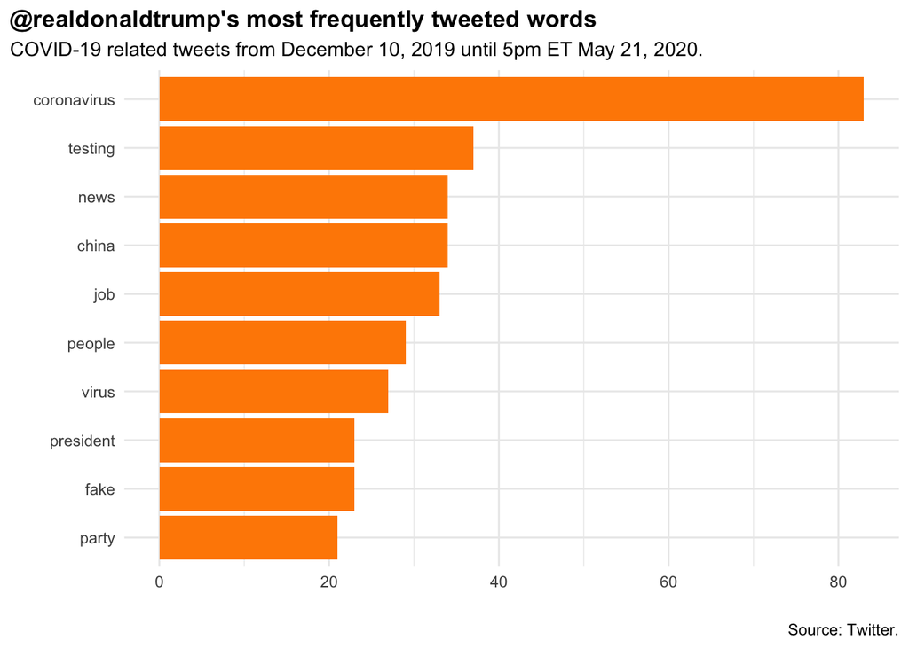

# Sentiment

In addition to summarizing the frequency of words, we can also analyze the sentiment of the tweets. A simple approach is to analyze sentiment at the word level and summarize across words in a collection.

[`{tidytext}`](https://www.tidytextmining.com/sentiment.html) has three built in sentiment lexicons: `AFINN`, `bing`, and `nrc`.

> All three of these lexicons are based on unigrams, i.e., single words. These lexicons contain many English words and the words are assigned scores for positive/negative sentiment, and also possibly emotions like joy, anger, sadness, and so forth. The nrc lexicon categorizes words in a binary fashion (“yes”/“no”) into categories of positive, negative, anger, anticipation, disgust, fear, joy, sadness, surprise, and trust. The bing lexicon categorizes words in a binary fashion into positive and negative categories. The AFINN lexicon assigns words with a score that runs between -5 and 5, with negative scores indicating negative sentiment and positive scores indicating positive sentiment.

| word | afinn | bing | nrc |
| --- | --- | --- | --- |
| absentee | -1 | negative | negative |
| absentee | -1 | negative | sadness |
| abuse | -3 | negative | anger |
| abuse | -3 | negative | disgust |
| abuse | -3 | negative | fear |
| abuse | -3 | negative | negative |
| abuse | -3 | negative | sadness |
| accidental | -2 | negative | fear |
| accidental | -2 | negative | negative |
| accidental | -2 | negative | surprise |

For instance, we can look for words in the President’s tweets that are labeled as “anger” in the `nrc` lexicon. We’ll do this with `inner_join`, a mutating join:

> return all rows from x where there are matching values in y, and all columns from x and y. If there are multiple matches between x and y, all combination of the matches are returned.

| word | n |
| --- | --- |
| bad | 11 |
| force | 9 |
| crazy | 6 |
| enemy | 6 |
| fight | 6 |
| hit | 6 |
| hoax | 6 |
| money | 5 |
| blatant | 4 |
| crime | 4 |

Let’s go back to the President’s full collection of COVID-era tweets, use the `bing` lexicon to identify positive and negative sentiments, count positive/negative sentiment words by day, and plot.

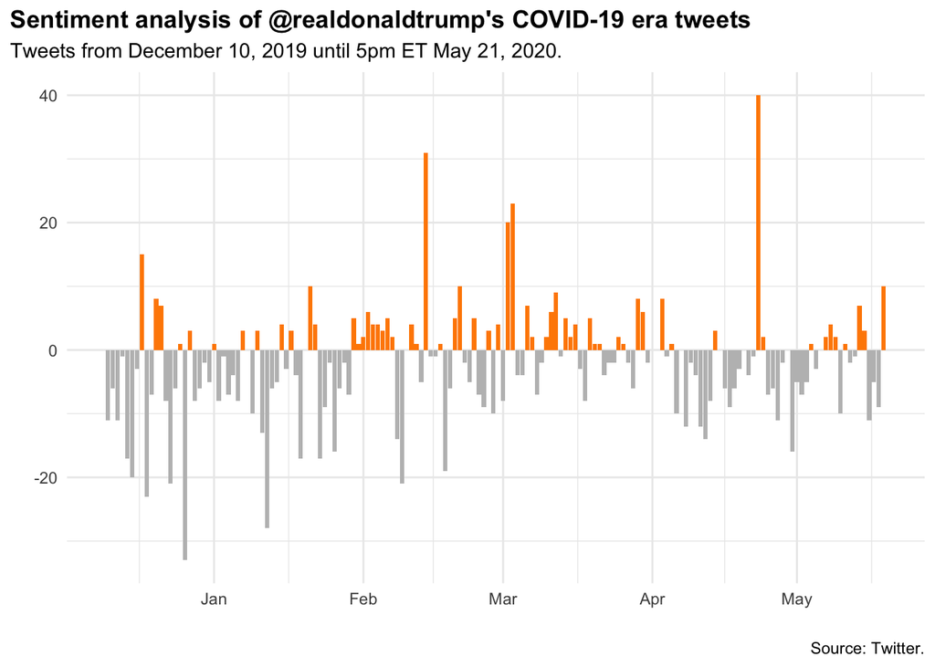

What’s the big spike of positivity on April 23? Let’s have a look.

| text |
| --- |
| Governor @JimJusticeWV is a tremendous fighter for the incredible people of West Virginia. Big Jim is strong on Life the Second Amendment and Building the Wall! With Governors like Jim America will re… |
| Congressman @SteveStivers is doing a terrific job for the People of Ohio! He defends our Borders Supports our Veterans Strong on Crime and the Second Amendment. Steve has my Complete and Total Endorse… |
| Congressman Bill Posey is a tremendous fighter for the Great State of Florida. He is a big supporter of our #MAGA Agenda – Strong on Crime the Second Amendment and Loves our Veterans and Law Enforceme… |
| Congressman @MikeTurnerOH is a strong supporter and fighter for the People of Ohio! He will help us #MAGA! He’s Strong on the Border Tough on Crime will Protect our Vets and our GREAT Second Amendment… |
| Congressman @Troy_Balderson is doing a GREAT job for the People of Ohio! He will always Protect your #2A Defend our Borders and Support Small Business – a great supporter of the #MAGA Agenda. Troy has… |
| Congressman @DaveJoyceOH14 is a tremendous fighter for the Great State of Ohio! He is Tough on Crime our Border Second Amendment and helps us Combat Illegal Drugs! David has my Complete and Total Endo… |
| Congressman @BradWenstrup is doing a tremendous job for the People of Ohio! He’s a proud Veteran and is Strong on the Border Tough on Crime the Second Amendment and Supports Small Business. Brad has m… |
| ….My co-chair in Utah and a really great guy. Sean has my Complete and Total Endorsement! |
| Utah Attorney General Sean Reyes (@SeanReyesUT) is a fighter and hard worker for the Great State of Utah. He is a big supporter of our #MAGA Agenda – Strong on Crime the Second Amendment and Loves our… |
| Congressman John Curtis (@CurtisUT) gets things done for Utah! John fights for Small Businesses will Lower your Taxes and will protect your Second Amendment. He has my Complete and Total Endorsement! |
| Congressman Chris Stewart (@StewartforUtah) is a tremendous fighter for Utah. He served our Country in the U.S. Air Force and has been a strong supporter of our #MAGA Agenda…. |
| ….He’s 100% pro-life strong on #2A and Loves our Military and Vets. Chris has my Complete and Total Endorsement! https://t.co/7w8Ayt5Bsq |
| Congressman Warren Davidson (@Vote_Davidson) is working very hard for the people of Ohio! He’s a strong supporter of our Military Vets Second Amendment and #MAGA Agenda. Warren has my Complete and Tot… |
| ….Bill has my Complete and Total Endorsement! https://t.co/Dmso0XmeYl |
| Congressman Bill Johnson (@JohnsonLeads) is an incredible fighter for the Great State of Ohio! He’s a proud Veteran and a hard worker who Cares for our Veterans Supports Small Business and is Strong o… |
| I will be having a White House Press Conference today at 5:45 P.M. Thank you! |
| https://t.co/iPon70Z1yW |
| https://t.co/cT7EDnDUYo |
| https://t.co/R3mSfNIeC6 |
| Fully signed and ready to go! https://t.co/MdpgII3kuq |
| Please study this closely. We saved many lives with our fast action on CoronaVirus! https://t.co/IKtkciXEEO |
| We did it once we will quickly do it a second time! https://t.co/iSHk0JIMSV |
| Thank you to Harvard and all others! https://t.co/UH15FJ5SqV |
| .@foxandfriends We now have many Ventilators to spare. Thank you to all! https://t.co/brNmQKZ1FL |

# Bigrams

It’s also common to look at consecutive sequences of words called n-grams. Sequences of two consecutive words are called bigrams. Extracting n-grams is easy with `unnest_tokens()` using the parameters `token = "ngrams"` and `n`. The words are extracted as one string, so we need to use `separate()` to separate these words into two columns at the space.

| word1 | word2 | n |
| --- | --- | --- |
| fake | news | 138 |
| white | house | 66 |
| impeachment | hoax | 63 |
| mini | mike | 53 |
| total | endorsement | 51 |
| radical | left | 43 |
| republican | party | 40 |
| lamestream | media | 33 |
| sleepy | joe | 30 |
| 00 | p.m | 28 |

With a richer dataset you can do a lot more to explore the relationships between words, but our corpus of tweets is relatively small, and tweets are short by design. Check out some [`{tidytext}` examples](https://www.tidytextmining.com/ngrams.html#tokenizing-by-n-gram) using Jane Austin books.